# Android vs. iPhone

- Show All Code
- Hide All Code

Course DS 350

Author

Brian Munoz

```r
library(readxl)
library(readr)
library(dplyr)
library(ggplot2)
library(dplyr)
library(tidyr)
library(stringr)
library(tidyverse)
library(viridis)
library(patchwork)
```

*Market Shares 2014*

**Lets First start analyzing how were the market shares in the year 2014 from statcounter. We can see that Android and iOS are the ones that posses most of the market, been the combine market share a total of 77.5% between the two of them. Among this two Android has shown that posses more than 50% of the global market share. Although iOS posses around 24% of the market shares globaly, is interesting to see that in North america has almost the 50% percent. Which could cause confusion over preference if we only observe the data in places such as United States.**

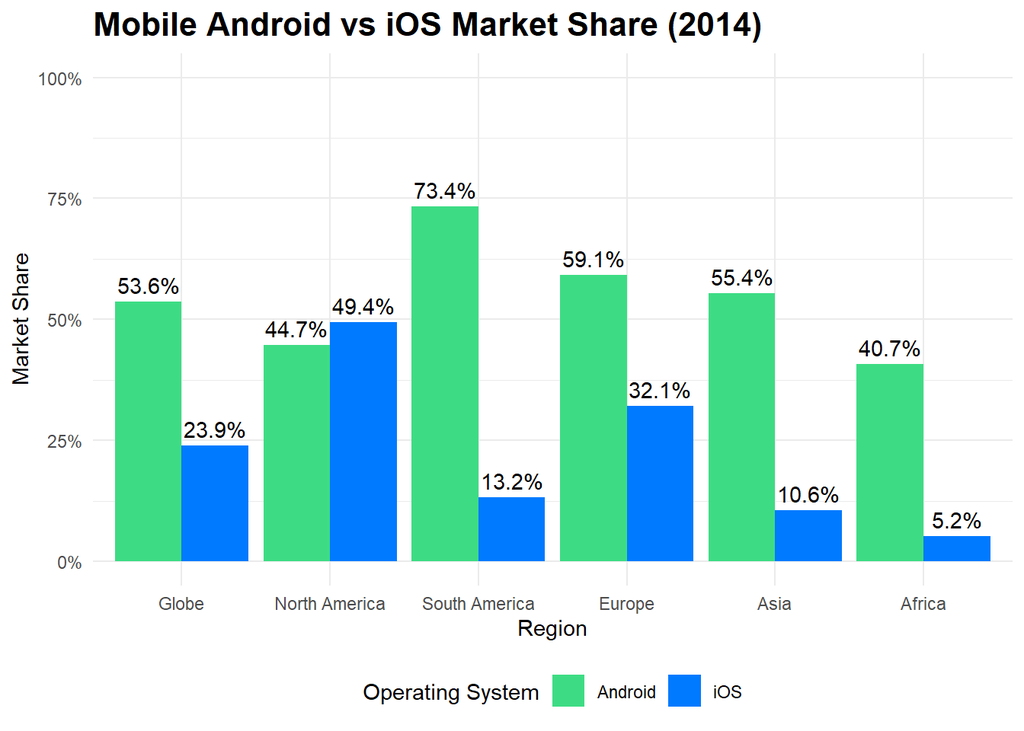

```r
#Market Share Analysis 10 years ago

# Combine the data into a single dataframe

files <- c("Market_Europe.csv", "Market_North_America.csv", "Market_South_America.csv", "Market_world_wide.csv", "Market_Asia.csv", "Market_Africa.csv")

regions <- c("Europe", "North America", "South America", "Globe", "Asia", "Africa")

data_list <- lapply(files, read_csv)
names(data_list) <- regions

combined_data <- bind_rows(data_list, .id = "Region")

# Divide the market share values by 100 to convert to percentages
combined_data$Android <- combined_data$Android / 100
combined_data$iOS <- combined_data$iOS / 100

# Filter for only 2024 data
data_2024 <- combined_data %>% filter(Date == 2014)

# Pivot the data to long format
data_long <- data_2024 %>%
  pivot_longer(cols = c("Android", "iOS"), names_to = "OS", values_to = "Market_Share")

# Reorder the regions
data_long$Region <- factor(data_long$Region, levels = c("Globe", "North America", "South America", "Europe", "Asia", "Africa"))


# Create the plot
ggplot(data_long, aes(x = Region, y = Market_Share, fill = OS)) +
  geom_bar(stat = "identity", position = "dodge") +
  scale_y_continuous(labels = scales::percent, limits = c(0, 1)) +
  scale_fill_manual(values = c("Android" = "#3DDC84", "iOS" = "#007AFF")) +
  geom_text(aes(label = scales::percent(Market_Share)), position = position_dodge(width = 0.9), vjust = -0.5) +
  labs(
    title = "Mobile Android vs iOS Market Share (2014)",
    x = "Region",
    y = "Market Share",
    fill = "Operating System"
  ) +
  theme_minimal() +
  theme(
    plot.title = element_text(size = 16, face = "bold"),
    axis.text.x = element_text(angle = 0, hjust = 0.5),
    legend.position = "bottom"
  )
```

*Market Shares 2024*

**This tell us that globaly, the average person preference Android over iOS. This could be for multiple reasons but I believe that one of the biggest impacts in the income of the average person. We will be explore more about this in the next point.**

[figure not shown]

```r
#Market Share Analysis Now

data_list <- lapply(files, read_csv)
names(data_list) <- regions

combined_data <- bind_rows(data_list, .id = "Region")

# Divide the market share values by 100 to convert to percentages
combined_data$Android <- combined_data$Android / 100
combined_data$iOS <- combined_data$iOS / 100

# Filter for only 2024 data
data_2024 <- combined_data %>% filter(Date == 2024)

# Pivot the data to long format
data_long <- data_2024 %>%
  pivot_longer(cols = c("Android", "iOS"), names_to = "OS", values_to = "Market_Share")

# Reorder the regions
data_long$Region <- factor(data_long$Region, levels = c("Globe", "North America", "South America", "Europe", "Asia", "Africa"))

# Create the plot
ggplot(data_long, aes(x = Region, y = Market_Share, fill = OS)) +
  geom_bar(stat = "identity", position = "dodge") +
  scale_y_continuous(labels = scales::percent, limits = c(0, 1)) +
  scale_fill_manual(values = c("Android" = "#3DDC84", "iOS" = "#007AFF")) +
  geom_text(aes(label = scales::percent(Market_Share)), position = position_dodge(width = 0.9), vjust = -0.5) +
  labs(
    title = "Mobile Android vs iOS Market Share (2014)",
    x = "Region",
    y = "Market Share",
    fill = "Operating System"
  ) +
  theme_minimal() +
  theme(
    plot.title = element_text(size = 16, face = "bold"),
    axis.text.x = element_text(angle = 0, hjust = 0.5),
    legend.position = "bottom"
  )
```

*Market Shares Growth:*

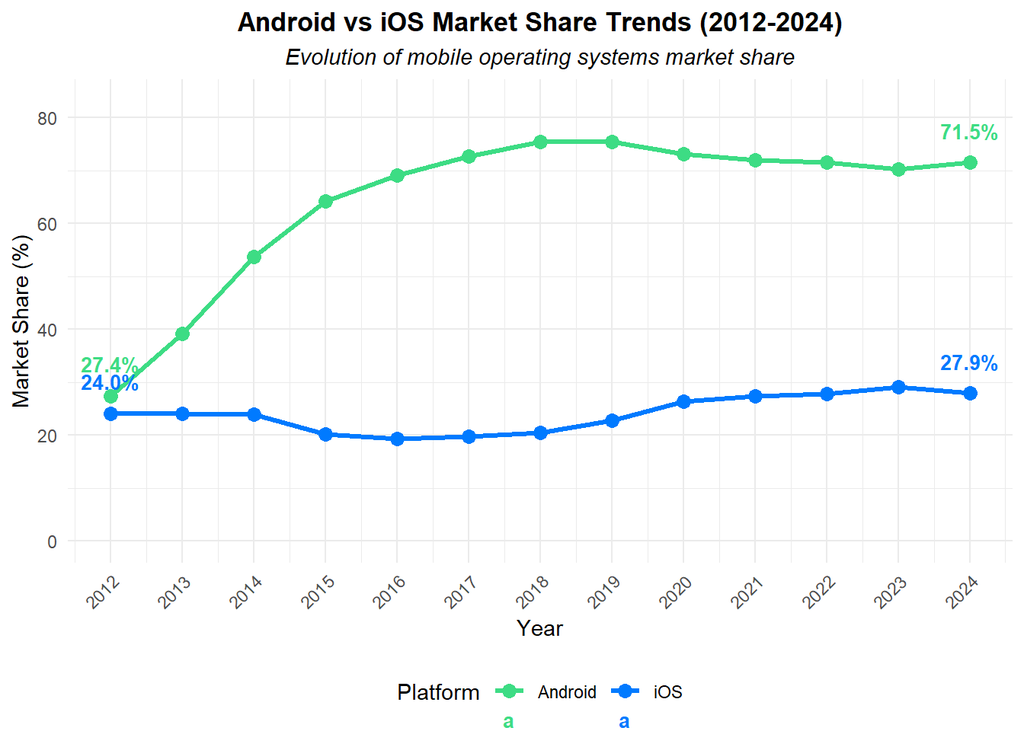

```r
#Market share time line


# Read the CSV file
# Replace the path with the correct path to your file
market_data <- read_csv("Market_world_wide.csv")

# Convert data to long format for easier plotting
market_data_long <- market_data %>%
  pivot_longer(cols = c(Android, iOS),
               names_to = "Platform",
               values_to = "Market_Share")

# Select start and end points for labeling
label_data <- market_data_long %>%
  group_by(Platform) %>%
  filter(Date %in% c(min(market_data$Date), max(market_data$Date)))

# Create the trendline plot
ggplot(market_data_long, aes(x = Date, y = Market_Share, color = Platform, group = Platform)) +
  geom_line(size = 1.2) +
  geom_point(size = 3) +

  # Add text labels for start and end points
  geom_text(data = label_data,
            aes(label = paste0(sprintf("%.1f%%", Market_Share))),
            vjust = -1.5,
            hjust = 0.5,
            size = 3.5,
            fontface = "bold") +

  labs(
    title = "Android vs iOS Market Share Trends (2012-2024)",
    subtitle = "Evolution of mobile operating systems market share",
    x = "Year",
    y = "Market Share (%)",
    color = "Platform"
  ) +
  theme_minimal() +
  theme(
    plot.title = element_text(hjust = 0.5, face = "bold"),
    plot.subtitle = element_text(hjust = 0.5, face = "italic"),
    legend.position = "bottom",
    axis.text.x = element_text(angle = 45, hjust = 1)
  ) +
  scale_color_manual(values = c("Android" = "#3DDC84", "iOS" = "#007AFF")) +

  # Ensure all years are shown on x-axis
  scale_x_continuous(breaks = market_data$Date,
                     labels = as.character(market_data$Date)) +

  # Extend y-axis slightly to make room for labels
  expand_limits(y = c(0, max(market_data_long$Market_Share) * 1.1))
```

*Average Price*

**We can see that in average not only the starting price of devices is not just significatly different, but that we can see that the average iOS user tends to spend more money that the Andorid users. This will help us see why the income is so important in the divece selection process.**

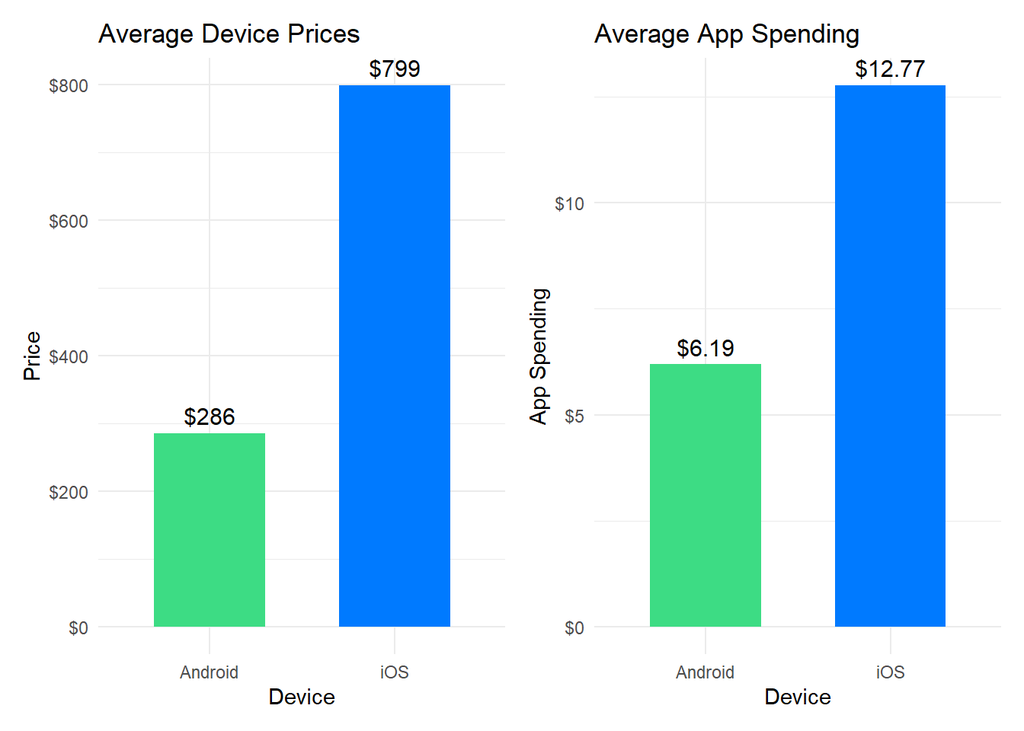

```r
# Data
android_price <- 286
ios_price <- 799
android_app_spend <- 6.19
ios_app_spend <- 12.77

# Device Price Comparison
device_data <- data.frame(
  Device = c("Android", "iOS"),
  Price = c(android_price, ios_price)
)
device_price_plot <- ggplot(device_data, aes(x = Device, y = Price, fill = Device)) +
  geom_bar(stat = "identity", width = 0.6) +
  geom_text(aes(label = sprintf("$%g", Price)), vjust = -0.5, size = 4) +
  scale_y_continuous(labels = scales::dollar) +
  scale_fill_manual(values = c("Android" = "#3DDC84", "iOS" = "#007AFF")) +  # Changed from scale_color_manual to scale_fill_manual
  labs(
    title = "Average Device Prices",
    x = "Device",
    y = "Price"
  ) +
  theme_minimal() +
  theme(legend.position = "none")

# App Spending Comparison
app_data <- data.frame(
  Device = c("Android", "iOS"),
  AppSpending = c(android_app_spend, ios_app_spend)
)
app_spend_plot <- ggplot(app_data, aes(x = Device, y = AppSpending, fill = Device)) +
  geom_bar(stat = "identity", width = 0.6) +
  geom_text(aes(label = sprintf("$%.2f", AppSpending)), vjust = -0.5, size = 4) +
  scale_y_continuous(labels = scales::dollar) +
  scale_fill_manual(values = c("Android" = "#3DDC84", "iOS" = "#007AFF")) +  # Changed from scale_color_manual to scale_fill_manual
  labs(
    title = "Average App Spending",
    x = "Device",
    y = "App Spending"
  ) +
  theme_minimal() +
  theme(legend.position = "none")

# Display the plots side-by-side
device_price_plot + app_spend_plot
```

*Income Analysis*

**We can see in the following graph that the average annual income, which is income before taxes, is, according to WorldData.ifo, only $17,771. We now now that that base on the average spending and income of the customers, is safe to assume that one of the biggest reasons iOS has been unable to control more of the market share is because of prices. We can expect that until iOS is able to reduce their prices people will tend to select Android over iOS base on prices only.**

*Why does Europe, region with higher acquisition power than North America, choices Android over iPhone?*

*Due to the regulations imposed on iOS in Europe, and the fact that they refuse to comply with all the regulations imposed on them, it has been difficult for iOS to gain more presence in European countries. This explains why countries with high purchasing power choose Android over Apple.*

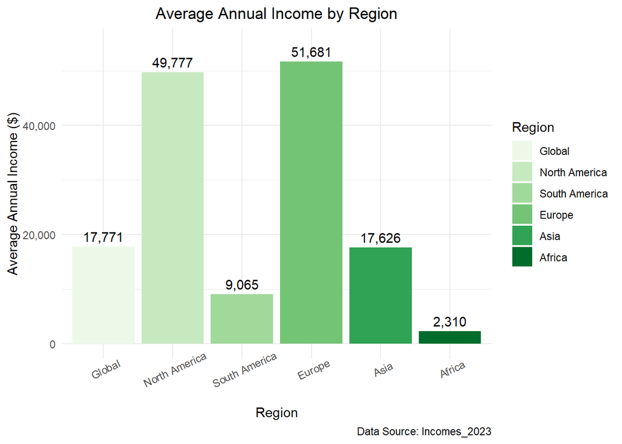

```r
# Average Income Histogram

# Read the data
Incomes_2023 <- read_excel("Incomes_2023.xlsx", sheet = "Average_Income")

# Reorder the regions
Incomes_2023$Region <- factor(Incomes_2023$Region, levels = c("Global", "North America", "South America", "Europe", "Asia", "Africa"))

# Create the histogram
ggplot(Incomes_2023, aes(x = Region, y = `Average Annual Income ($)`, fill = Region)) +
  geom_bar(stat = "identity", position = position_dodge(width = 0.5)) +
  geom_text(aes(label = scales::comma(`Average Annual Income ($)`)), position = position_dodge(width = 0.9), vjust = -0.5) +
  scale_y_continuous(labels = scales::comma, limits = c(0, 55000)) +
  theme_minimal() +
  labs(
    title = "Average Annual Income by Region",
    x = "Region",
    y = "Average Annual Income ($)",
    caption = "Data Source: Incomes_2023"
  ) +
  theme(
    axis.text.x = element_text(angle = 25, hjust = 0.5),
    plot.title = element_text(hjust = 0.5)
  ) +
  scale_fill_brewer(palette = "BrewerGreen")
```

*Fun Facts in the USA (Source: statista)*

*Does Age affect what divice you chooce?*

**We do not adentify a significant difference, the only interesting fact is that the yonger population tends to lead towards the iOS device instead of the cheper option.**

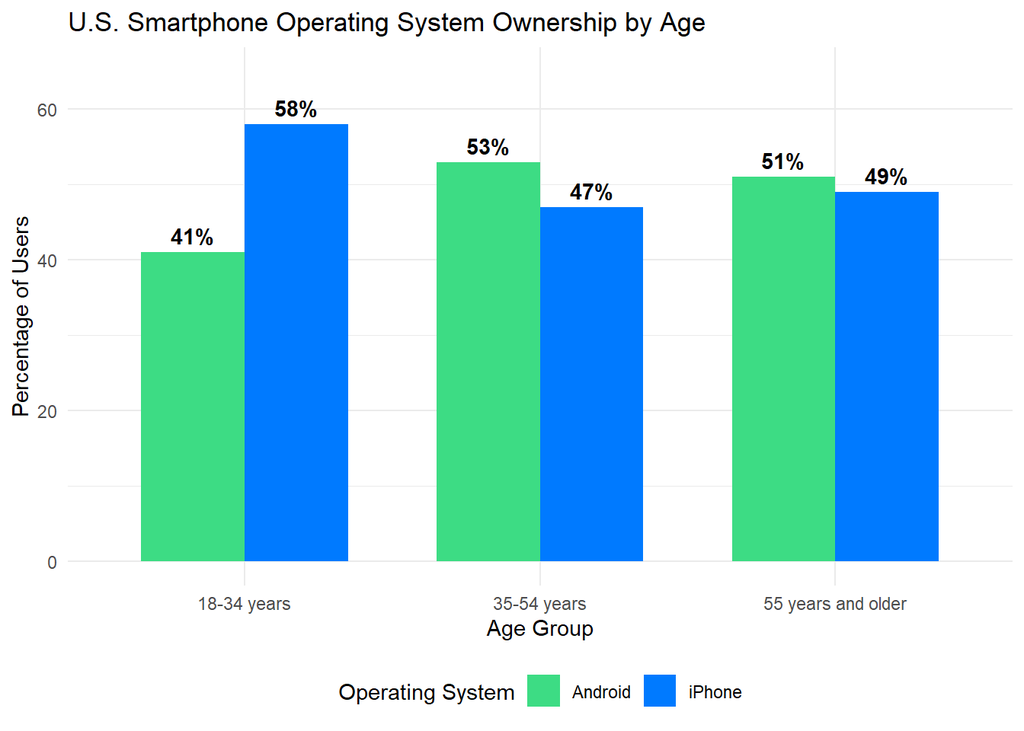

```r
smartphone_data <- data.frame(
  Age = c("18-34 years", "35-54 years", "55 years and older"),
  iPhone = c(58, 47, 49),
  Android = c(41, 53, 51)
)

# Reshape the data to long format
smartphone_long <- pivot_longer(smartphone_data,
                                cols = c(iPhone, Android),
                                names_to = "OS",
                                values_to = "Percentage")

# Create grouped bar chart with labels
chart <- ggplot(smartphone_long, aes(x = Age, y = Percentage, fill = OS)) +
  geom_bar(stat = "identity", position = "dodge", width = 0.7) +
  # Add text labels on top of each bar
  geom_text(aes(label = paste0(Percentage, "%")),
            position = position_dodge(width = 0.7),
            vjust = -0.5,
            fontface = "bold") +
  labs(
    title = "U.S. Smartphone Operating System Ownership by Age",
    x = "Age Group",
    y = "Percentage of Users",
    fill = "Operating System"
  ) +
  # Extend y-axis to make room for labels
  ylim(0, 65) +
  scale_fill_manual(values = c("iPhone" = "#007AFF", "Android" = "#3DDC84")) +
  theme_minimal() +
  theme(legend.position = "bottom")

# Save the chart
ggsave("smartphone_os_by_age.png", chart, width = 8, height = 6)

# Display the chart
print(chart)
```

*Is there a difference correlated to Gender?*

**We can see that the result of the analysis follow the trend world wide, and that gender is not as relevant when taking the decision of choosing devices.**

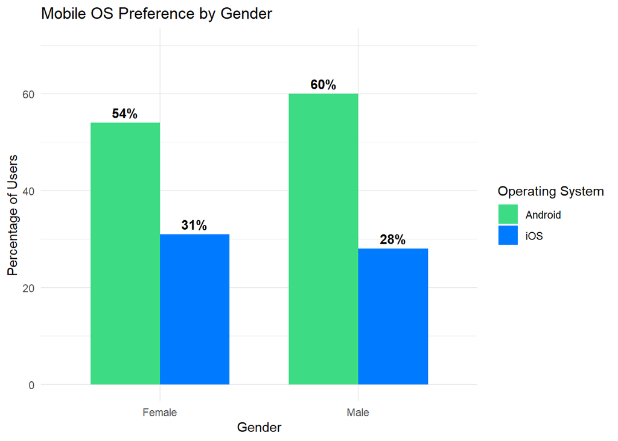

```r
# Mobile OS Preference Analysis by Gender


# Create data frame
mobile_os_data <- data.frame(
  Gender = c("Female", "Male"),
  iOS = c(31, 28),
  Android = c(54, 60)
)

# Reshape data for grouped bar chart
mobile_os_long <- pivot_longer(
  mobile_os_data,
  cols = c(iOS, Android),
  names_to = "OS",
  values_to = "Percentage"
)

# Create grouped bar chart
os_preference_chart <- ggplot(mobile_os_long,
                               aes(x = Gender, y = Percentage, fill = OS)) +
  geom_bar(stat = "identity", position = "dodge", width = 0.7) +
  labs(
    title = "Mobile OS Preference by Gender",
    y = "Percentage of Users",
    x = "Gender",
    fill = "Operating System"
  ) +
  theme_minimal() +
  scale_fill_manual(values = c("Android" = "#3DDC84", "iOS" = "#007AFF")) +
  geom_text(
    aes(label = paste0(Percentage, "%")),
    position = position_dodge(width = 0.7),
    vjust = -0.5,
    fontface = "bold"
  ) +
  ylim(0, 70)

# Save the plot
ggsave("mobile_os_preference_grouped_barchart.png", os_preference_chart, width = 8, height = 6)

# Display the plot (useful in R Studio)
print(os_preference_chart)
```